# Trabajo Práctico 3: Análisis de Componentes Principales

Carlos Brutomeso

06/05/2025

Para este trabajo práctico se trabajará sobre la base de datos de FIFA 2024 MEN. Setear la semilla con los últimos 3 digitos del DNI para obtener una muestra de 2000 individuos.

```r
# Instalación (si aún no están instalados)
#install.packages("tidyverse", repos = "https://cloud.r-project.org")
#install.packages("ggplot2", repos = "https://cloud.r-project.org")
#install.packages("skimr", repos = "https://cloud.r-project.org")
#install.packages("factoextra", repos = "https://cloud.r-project.org")
#install.packages("rrcov", repos = "https://cloud.r-project.org")
#install.packages("ggrepel", repos = "https://cloud.r-project.org")

# Carga de librerías
library(tidyverse)
library(ggplot2)
library(skimr)
library(factoextra)
library(rrcov)
library(ggrepel)

wd <- "player_stats.csv"

df <- read.csv(wd)

set.seed(375) #cambiar por los 3 digitos del DNI.

sample <- df %>%
          sample_n(2000)# muestreo aletorio de 2000 individuos
```

# Objetivo

Aplicar el Análisis de Componentes Principales (PCA) para reducir la dimensionalidad del dataset de FIFA 2024 Men, identificar patrones en los datos y visualizar cómo se agrupan los jugadores en función de sus características.

# Análisis exploratorio de datos y preprocesamiento

**1- Analice la presencia de valores faltantes y datos duplicados.**

Se analizó la proporción de valores faltantes para cada variable del conjunto de datos. Solo una variable presentó valores faltantes de forma completa: `marking`, con el 100% de observaciones ausentes. Esto indica que no aporta información útil para el análisis y puede eliminarse sin pérdida de información relevante. Todas las demás variables se encuentran completas, sin valores faltantes.

En cuanto a los datos duplicados, se verificó si existían jugadores repetidos utilizando la variable `player` como identificador. Se detectaron 3 jugadores con el mismo nombre, aunque no se encontraron filas duplicadas completas. Esto indica que los registros corresponden a jugadores distintos con el mismo nombre o múltiples versiones válidas de un mismo jugador (por ejemplo, con diferentes clubes o atributos en distintas ediciones del juego). Por tanto, no se requiere eliminación de filas.

```r
# Visualizar estructura básica
str(sample)
```

```
## 'data.frame':    2000 obs. of  41 variables:
##  $ player        : chr  "Tin Jedvaj" "Florent Hanin" "Jhonder Cádiz" "Marin Pongračić" ...
##  $ country       : chr  "Croatia" "France" "Venezuela" "Croatia" ...
##  $ height        : int  185 177 191 193 175 182 185 178 187 185 ...
##  $ weight        : int  83 73 85 97 72 73 77 67 76 84 ...
##  $ age           : int  27 33 28 25 30 24 35 28 27 31 ...
##  $ club          : chr  "Al Ain FC " "Paris FC " "FC Famalicão " "Lecce " ...
##  $ ball_control  : int  65 66 69 64 64 91 68 58 58 58 ...
##  $ dribbling     : int  62 66 70 63 63 93 72 60 60 54 ...
##  $ marking       : chr  "None" "None" "None" "None" ...
##  $ slide_tackle  : int  72 66 24 76 63 32 29 57 26 63 ...
##  $ stand_tackle  : int  74 67 31 77 61 34 26 59 34 68 ...
##  $ aggression    : int  76 68 70 77 74 64 64 57 45 72 ...
##  $ reactions     : int  68 67 70 70 60 93 71 55 56 65 ...
##  $ att_position  : int  49 60 70 28 55 92 71 54 57 28 ...
```

[output cut: 27 more lines]

```r
# Convertir 'value' a variable numérica
sample <- sample %>%
  mutate(
    value_clean = gsub("\\$", "", value),           # 1. Eliminar símbolo $
    value_clean = gsub("\\.", "", value_clean),     # 2. Eliminar puntos (separadores de miles)
    value_num = as.numeric(value_clean),            # 3. Convertir a numérico
    value_num = ifelse(value_num < 100000, value_num * 10, value_num) # 4. Corregir valores bajos
  )

# Convertir 'marking' a variable entera
sample <- sample %>%
  mutate(
    marking = as.integer(marking)
  )
# Proporción de valores faltantes por columna
missing_summary <- sample %>%
  summarise(across(everything(), ~mean(is.na(.)))) %>%
  pivot_longer(cols = everything(), names_to = "variable", values_to = "prop_missings") %>%
  arrange(desc(prop_missings))

print(missing_summary, n = Inf)
```

```
## # A tibble: 43 × 2
##    variable       prop_missings
##    <chr>                  <dbl>
##  1 marking                    1
##  2 player                     0
##  3 country                    0
##  4 height                     0
##  5 weight                     0
##  6 age                        0
##  7 club                       0
##  8 ball_control               0
##  9 dribbling                  0
## 10 slide_tackle               0
## 11 stand_tackle               0
## 12 aggression                 0
```

[output cut: 31 more lines]

```r
# Revisar duplicados (filas idénticas completas)
duplicated_rows <- sample %>%
  duplicated() %>%
  sum()

cat("Cantidad de filas duplicadas:", duplicated_rows, "\n")
```

```
## Cantidad de filas duplicadas: 0
```

```r
duplicated_players <- sample %>%
  filter(duplicated(player))

cat("Cantidad de jugadores duplicados:", nrow(duplicated_players), "\n")
```

```
## Cantidad de jugadores duplicados: 3
```

**2- Seleccione un subconjunto de variables relevantes para realizar el PCA. Justifique la selección.**

Para la realización del PCA se seleccionó un subconjunto de variables que combina atributos físicos y técnicos generales de los jugadores de campo. Se excluyeron las variables relacionadas exclusivamente con arqueros (por ejemplo, `gk_diving`, `gk_reflexes`) y el valor monetario (`value_num`), con el fin de enfocarse en características observables de desempeño y no en estimaciones de mercado.

El conjunto final de variables incluye:

- **Atributos físicos**: `height`, `weight`, `age`, `stamina`, `strength`, `sprint_speed`, `agility`
- **Atributos técnicos**: `ball_control`, `dribbling`, `short_pass`, `long_pass`

Esta selección permite capturar tanto el perfil físico (estatura, fuerza, velocidad) como el técnico (capacidad de pase, control y regate), resultando útil para identificar agrupamientos latentes entre jugadores en función de su estilo de juego y tipo corporal.

```r
# Selección de variables físicas y técnicas generales
pca_vars <- c("height", "weight", "age",
              "ball_control", "dribbling", "short_pass", "long_pass",
              "stamina", "strength", "sprint_speed", "agility")

# Crear nuevo dataframe con solo esas variables
sample_pca <- sample %>%
  select(all_of(pca_vars)) %>%
  drop_na()
```

**3- Realice una descripción de las variables numéricas seleccionadas.**

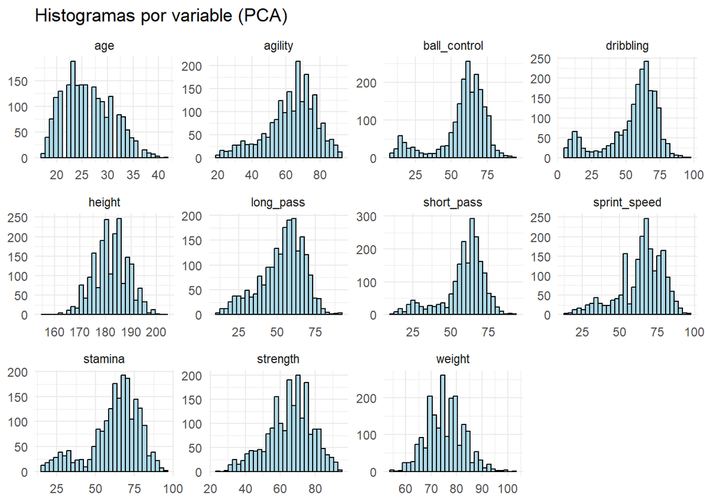

```r
# Convertir a formato largo para graficar múltiples histogramas
sample_pca_long <- sample_pca %>%
  pivot_longer(cols = everything(), names_to = "variable", values_to = "valor")

# Graficar histogramas por variable
ggplot(sample_pca_long, aes(x = valor)) +
  geom_histogram(bins = 30, fill = "lightblue", color = "black") +
  facet_wrap(~ variable, scales = "free", ncol = 4) +
  theme_minimal() +
  labs(title = "Histogramas por variable (PCA)", x = NULL, y = NULL)
```

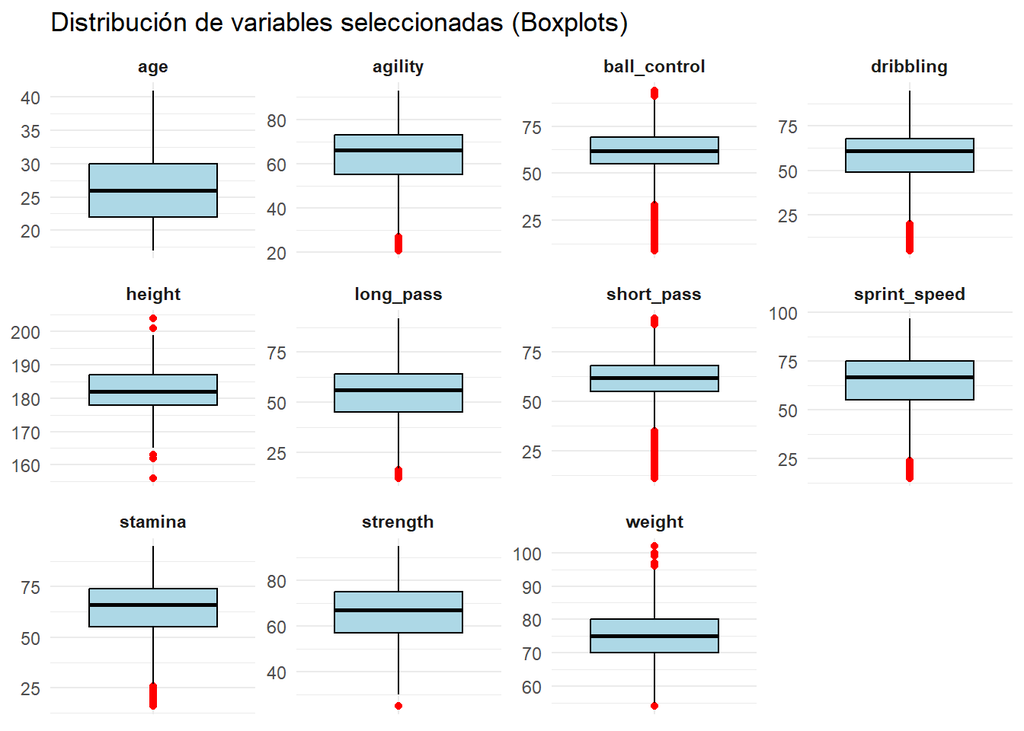

```r
# Crear boxplots
ggplot(sample_pca_long, aes(x = variable, y = valor)) +
  geom_boxplot(fill = "lightblue", color = "black", outlier.color = "red", outlier.size = 1.5) +
  facet_wrap(~ variable, scales = "free", ncol = 4) +
  theme_minimal() +
  labs(title = "Distribución de variables seleccionadas (Boxplots)",
       x = NULL, y = NULL) +
  theme(strip.text = element_text(face = "bold"),
        axis.text.x = element_blank(),
        axis.ticks.x = element_blank())
```

```r
# Generar estadísticas descriptivas
skim(sample_pca)
```

Data summary

| Name | sample_pca |
| --- | --- |
| Number of rows | 2000 |
| Number of columns | 11 |
| _______________________ |  |
| Column type frequency: |  |
| numeric | 11 |
| ________________________ |  |
| Group variables | None |

**Variable type: numeric**

| skim_variable | n_missing | complete_rate | mean | sd | p0 | p25 | p50 | p75 | p100 | hist |
| --- | --- | --- | --- | --- | --- | --- | --- | --- | --- | --- |
| height | 0 | 1 | 182.04 | 6.73 | 156 | 178 | 182 | 187 | 204 | ▁▃▇▆▁ |
| weight | 0 | 1 | 75.56 | 7.02 | 54 | 70 | 75 | 80 | 102 | ▁▆▇▂▁ |
| age | 0 | 1 | 26.19 | 4.83 | 17 | 22 | 26 | 30 | 41 | ▃▇▆▃▁ |
| ball_control | 0 | 1 | 58.29 | 16.75 | 9 | 55 | 62 | 69 | 94 | ▂▁▅▇▁ |
| dribbling | 0 | 1 | 55.37 | 18.97 | 5 | 49 | 61 | 68 | 95 | ▂▁▅▇▁ |
| short_pass | 0 | 1 | 58.96 | 14.25 | 11 | 55 | 62 | 68 | 92 | ▁▁▃▇▁ |
| long_pass | 0 | 1 | 53.37 | 14.37 | 12 | 45 | 56 | 64 | 92 | ▂▃▇▆▁ |
| stamina | 0 | 1 | 62.78 | 16.06 | 16 | 55 | 66 | 74 | 95 | ▁▁▅▇▂ |
| strength | 0 | 1 | 65.46 | 12.85 | 25 | 57 | 67 | 75 | 95 | ▁▂▇▇▂ |
| sprint_speed | 0 | 1 | 64.39 | 15.21 | 15 | 55 | 67 | 75 | 97 | ▁▂▅▇▂ |
| agility | 0 | 1 | 63.08 | 14.82 | 21 | 55 | 66 | 73 | 93 | ▁▂▆▇▂ |

**4- ¿Se estandarizaron las variables? Justifique.**

Sí, las variables fueron estandarizadas antes de aplicar el Análisis de Componentes Principales. Esta decisión se justifica por las siguientes razones:

- Las variables seleccionadas están medidas en escalas diferentes. Por ejemplo, `height` varía entre 156 y 204 centímetros, mientras que variables como `dribbling` o `ball_control` se expresan en una escala de 0 a 100 puntos.
- El PCA se basa en la varianza y covarianza entre variables. Si no se estandarizan, aquellas con mayor escala o dispersión dominarían las componentes principales, sesgando la interpretación del análisis.
- Por esta razón, todas las variables fueron transformadas en z-scores, es decir, se les restó su media y se dividieron por su desvío estándar. Esta transformación asegura que cada variable tenga media 0 y desvío estándar 1, otorgando igual peso a todas en la construcción de las componentes principales.

En R, la estandarización se realizó utilizando la función `scale()`, aplicada a las once variables seleccionadas para el PCA.

```r
# Escalar (estandarizar) las variables: z-score (media 0, sd 1)
sample_pca_scaled <- scale(sample_pca)

# Convertir a data.frame
sample_pca_scaled <- as.data.frame(sample_pca_scaled)
```

# PCA e interpretación.

**5- Realice el PCA sobre las variables seleccionadas. ¿Con cuantas componentes decide quedarse luego de la reduccion de dimensionalidad?**

Se aplicó el Análisis de Componentes Principales (PCA, por sus siglas en inglés) sobre las once variables estandarizadas previamente seleccionadas. El objetivo fue reducir la dimensionalidad conservando la mayor parte de la varianza total del conjunto de datos.

El scree plot muestra una fuerte caída en los primeros dos componentes, seguido por una disminución más gradual en los siguientes. Este patrón es indicativo de una estructura donde las primeras componentes concentran la mayor parte de la información.

La tabla de autovalores indica que la primera componente (`PC1`) tiene un autovalor de 5.86 y explica el 53.3% de la varianza total, mientras que la segunda componente (`PC2`) tiene un autovalor de 2.40 y explica un 21.8% adicional. En conjunto, las dos primeras componentes explican aproximadamente el 75.1% de la varianza acumulada.

Aplicando el criterio de Kaiser, que propone conservar únicamente aquellas componentes cuyo autovalor sea mayor a uno, se justifica la retención de dos componentes principales. Además, el scree plot muestra un quiebre claro (codo) después de la segunda componente, lo que refuerza esta elección desde el punto de vista visual. En función de estos resultados, se decidió conservar las dos primeras componentes principales. Esta decisión representa un equilibrio adecuado entre la simplificación del modelo y la capacidad explicativa, y permite capturar una estructura latente significativa sin incorporar ruido proveniente de componentes menores.

```r
# PCA
pca_result <- prcomp(sample_pca_scaled, center = FALSE, scale. = FALSE)

# Eigenvalues y varianza explicada
eigenvalues <- pca_result$sdev^2
diffs <- c(NA, diff(eigenvalues))
proportion <- eigenvalues / sum(eigenvalues)
cumulative <- cumsum(proportion)

# Crear tabla
pca_summary <- data.frame(
  Component = paste0("Comp", seq_along(eigenvalues)),
  Eigenvalue = round(eigenvalues, 2),
  Difference = round(diffs, 2),
  Proportion = round(proportion, 2),
  Cumulative = round(cumulative, 2)
)

print(pca_summary, row.names = FALSE)
```

```
##  Component Eigenvalue Difference Proportion Cumulative
##      Comp1       5.86         NA       0.53       0.53
##      Comp2       2.40      -3.47       0.22       0.75
##      Comp3       0.88      -1.52       0.08       0.83
##      Comp4       0.62      -0.26       0.06       0.89
##      Comp5       0.36      -0.26       0.03       0.92
##      Comp6       0.23      -0.12       0.02       0.94
##      Comp7       0.22      -0.01       0.02       0.96
##      Comp8       0.18      -0.04       0.02       0.98
##      Comp9       0.16      -0.03       0.01       0.99
##     Comp10       0.06      -0.10       0.01       1.00
##     Comp11       0.03      -0.03       0.00       1.00
```

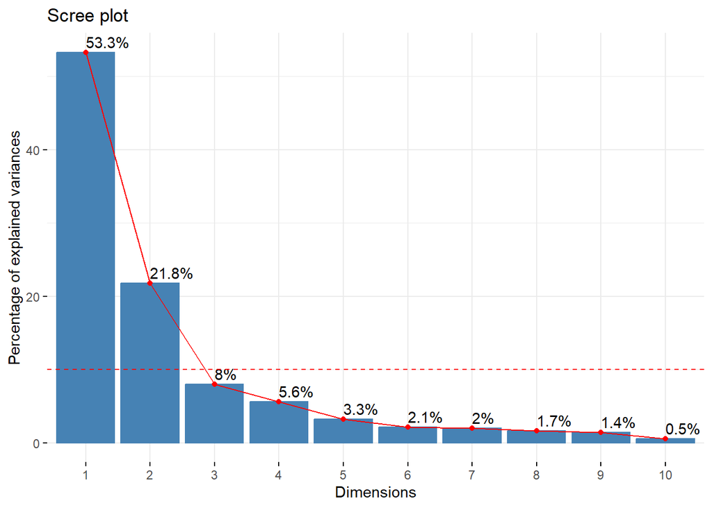

```r
# Scree plot con línea en y = 10
fviz_eig(pca_result, addlabels = TRUE, linecolor = "red") +
  geom_hline(yintercept = 10, linetype = "dashed", color = "red")
```

```r
# Extraer puntuaciones de los jugadores en las componentes principales
pca_scores <- as.data.frame(pca_result$x)

# Nos quedamos solo con PC1 y PC2
pca_scores <- pca_scores[, c("PC1", "PC2")]

# Unir PC1 y PC2 a la base original
sample_pca_with_scores <- cbind(sample, pca_scores)
```

**6- Interprete las cargas factoriales de las primeras dos componentes principales. ¿Qué atributos de los jugadores están más representados en cada componente? Mostrar el biplot del PCA realizado.**

El análisis de las cargas factoriales revela la estructura subyacente de los datos en el espacio reducido definido por las dos primeras componentes principales. La primera componente (`PC1`), que explica el 53.3 % de la varianza, está fuertemente influenciada por variables técnicas y físicas relacionadas con la movilidad y la calidad ofensiva. Entre ellas se destacan `agility`, `sprint_speed`, `dribbling`, `ball_control`, `short_pass` y `long_pass.` Todas estas variables presentan cargas positivas elevadas sobre `PC1`, lo que sugiere que esta dimensión sintetiza un eje de desempeño técnico-dinámico. En otras palabras, `PC1` distingue a los jugadores con mayores niveles de habilidad, velocidad y precisión en el manejo del balón.

El biplot permite visualizar gráficamente cómo se proyectan estas variables en el plano definido por las dos componentes. La orientación y longitud de los vectores reflejan el grado de asociación de cada variable con las componentes principales. Variables agrupadas y alineadas (por ejemplo, `short_pass` y `long_pass`) están positivamente correlacionadas, mientras que aquellas perpendiculares o opuestas representan dimensiones distintas.

En conjunto, el análisis muestra que los atributos más representativos en la primera componente son de tipo técnico y funcional, mientras que la segunda componente está más asociada a características físicas estructurales. Esta separación sugiere que el PCA logra capturar de forma efectiva dos dimensiones relevantes y complementarias en el análisis del perfil de los jugadores.

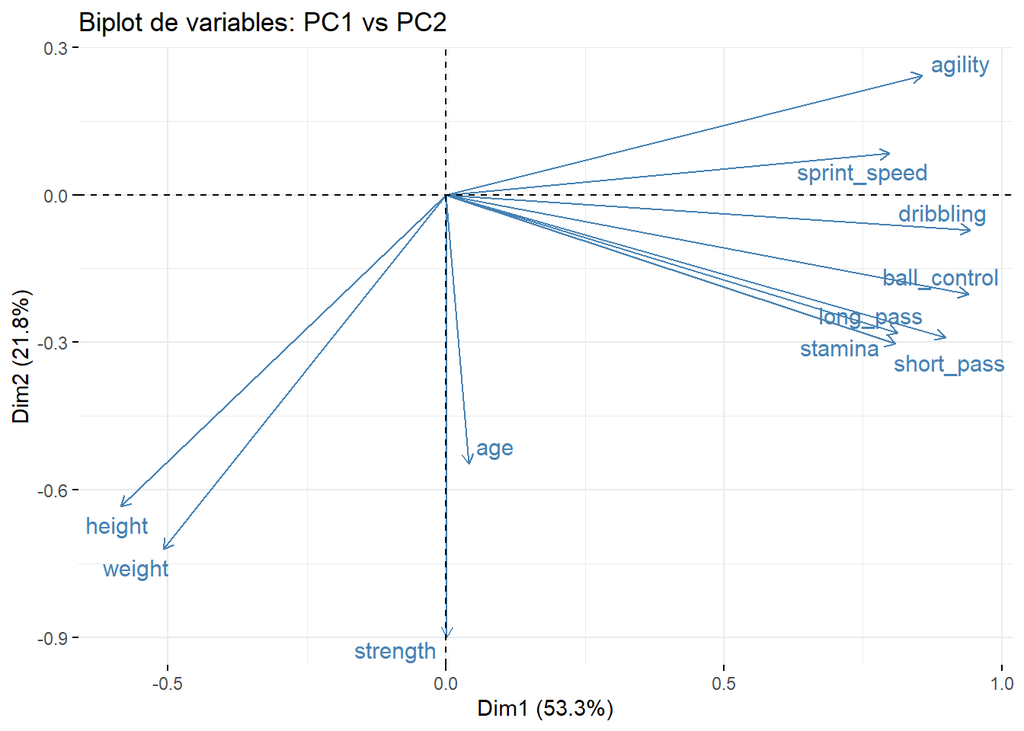

```r
# Biplot solo con las variables (cargas factoriales)
fviz_pca_var(pca_result,
             col.var = "steelblue",
             repel = TRUE,
             title = "Biplot de variables: PC1 vs PC2")
```

**7- Identifique si hay agrupamientos naturales de jugadores en función de las características seleccionadas. Interprete y concluya.**

Se exploró la existencia de agrupamientos naturales proyectando a los jugadores en el plano definido por las dos primeras componentes principales (`PC1` y `PC2`). La distribución visual sugiere la presencia de zonas de densidad diferenciadas.

Para cuantificar estos posibles agrupamientos, se aplicó el algoritmo k-means. Se evaluó el número óptimo de clusters utilizando dos métodos estadísticos complementarios: el método del codo (Elbow Method) y el índice de silueta promedio (Silhouette Method). El gráfico del codo sugiere un punto de inflexión claro en k = 3, donde la ganancia marginal en la reducción de la suma de cuadrados intra-cluster comienza a decrecer significativamente. No obstante, el método de silueta identifica un máximo local en k = 2, lo que sugiere que desde el punto de vista de separación entre grupos, dos clusters explicarían mejor la estructura del espacio. En este caso, se optó por conservar k = 3 debido a su mejor interpretación sustantiva: un grupo técnico, uno físico y uno de menor rendimiento. Además, los tres grupos obtenidos mostraron una segmentación coherente con los perfiles derivados del PCA.

Este análisis evidencia que, incluso tras una reducción de dimensionalidad, es posible identificar agrupamientos latentes coherentes con distintos perfiles de jugador. Los resultados del PCA y del clustering se complementan, permitiendo caracterizar y segmentar la muestra de manera interpretable.

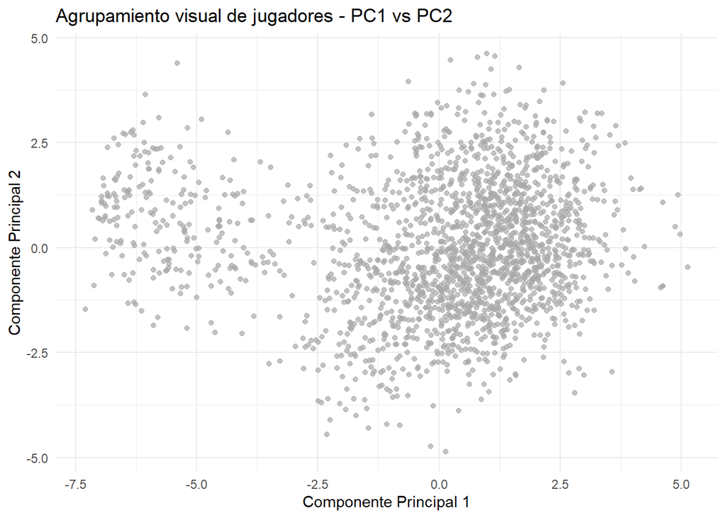

```r
# Scatter Plot
ggplot(sample_pca_with_scores, aes(x = PC1, y = PC2)) +
  geom_point(alpha = 0.7, color = "darkgray") +
  labs(
    title = "Agrupamiento visual de jugadores - PC1 vs PC2",
    x = "Componente Principal 1",
    y = "Componente Principal 2"
  ) +
  theme_minimal()
```

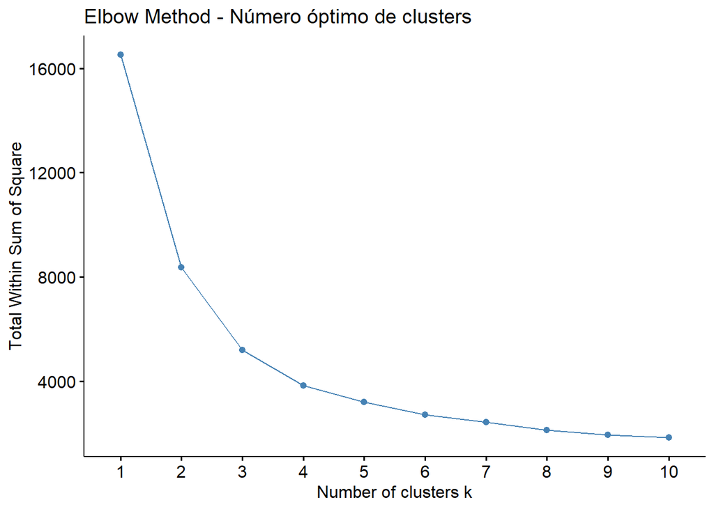

```r
# Elección óptima de clusters
fviz_nbclust(pca_scores[, c("PC1", "PC2")], kmeans, method = "wss") +
  labs(title = "Elbow Method - Número óptimo de clusters")
```

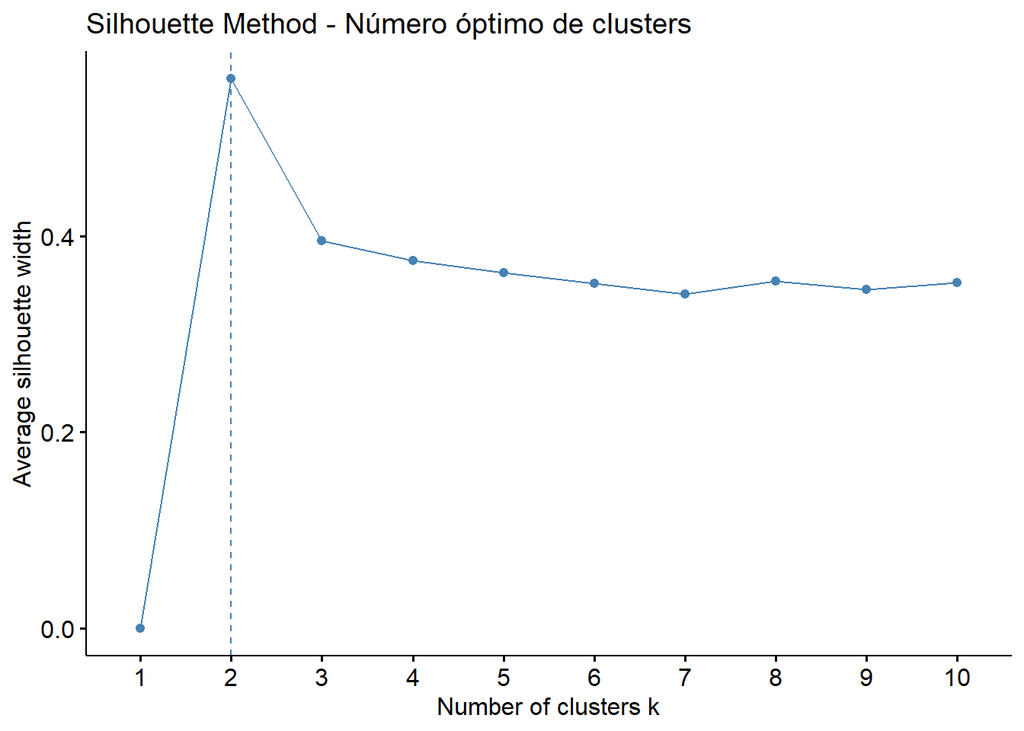

```r
fviz_nbclust(pca_scores[, c("PC1", "PC2")], kmeans, method = "silhouette") +
  labs(title = "Silhouette Method - Número óptimo de clusters")
```

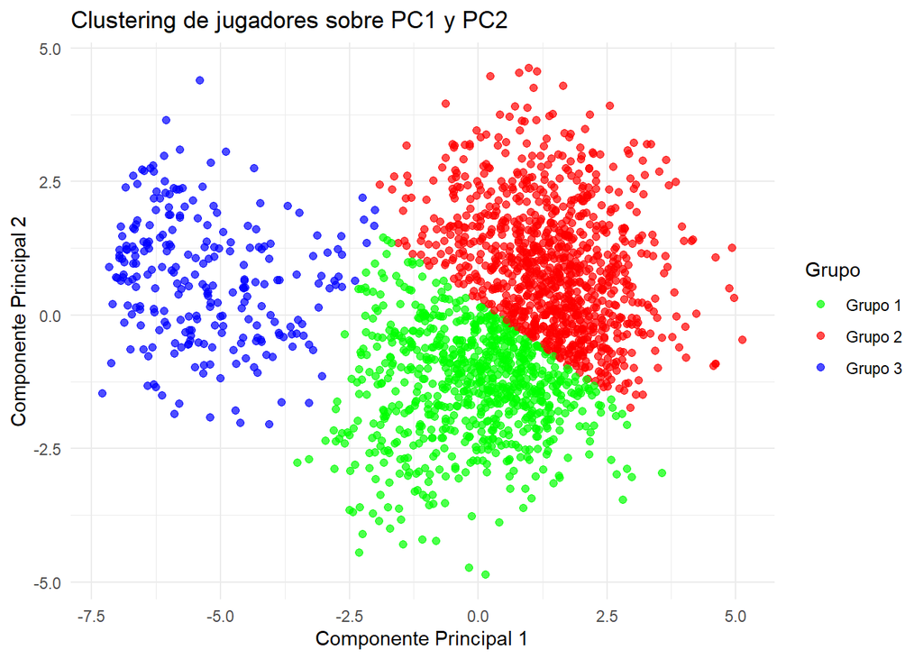

```r
# K-means con k = 3 sobre PC1 y PC2
kmeans_result <- kmeans(pca_scores[, c("PC1", "PC2")], centers = 3, nstart = 25)

# Agregar grupos al dataset
sample_pca_with_scores$grupo <- as.factor(kmeans_result$cluster)

# Plot
ggplot(sample_pca_with_scores, aes(x = PC1, y = PC2, color = grupo)) +
  geom_point(alpha = 0.7, size = 1.8) +
  scale_color_manual(values = c("green", "red", "blue"),
                     labels = c("Grupo 1", "Grupo 2", "Grupo 3")) +
  labs(title = "Clustering de jugadores sobre PC1 y PC2",
       x = "Componente Principal 1",
       y = "Componente Principal 2",
       color = "Grupo") +
  theme_minimal()
```

**8- Elegir una técnica de PCA robusto y aplicarla sobre la base de datos. Compare los resultados con los obtenidos anteriormente. Concluir.**

Se aplicó una versión robusta del Análisis de Componentes Principales utilizando el método RMCD (Minimum Covariance Determinant), una técnica diseñada para mitigar la influencia de valores atípicos multivariados. A diferencia del PCA clásico, que se basa en la matriz de covarianza estándar y por tanto es sensible a outliers, el enfoque robusto estima una matriz de correlación resistente construida a partir de un subconjunto central de las observaciones más representativas.

Los resultados muestran una distribución más equilibrada de la varianza explicada entre las componentes. En particular, la primera componente principal del PCA robusto explicó un 38 % de la varianza total, sensiblemente menor al 53.3 % observado en el análisis clásico. Esta diferencia puede sugerir que el PCA clásico podría haber sobreestimado la importancia de una única dimensión latente debido a la influencia de valores extremos. En contraste, el descenso en la varianza explicada por `PC1` y el mayor peso relativo de `PC2` y `PC3` en el enfoque robusto sugieren una estructura subyacente más distribuida y menos sesgada por observaciones atípicas. Se decidió conservar únicamente las dos primeras componentes principales, ya que explican el 65.4 % de la varianza total, presentan un quiebre claro en el scree plot y, si bien la tercera componente cumple el criterio de Kaiser, aporta una ganancia marginal reducida que no justifica la complejidad adicional para comparar con el PCA clásico.

Sin embargo, al contrastar los biplots del PCA clásico y el PCA robusto, se observa que, pese a la presencia de outliers revelada en los boxplots, el análisis clásico muestra una estructura más clara y direccional, especialmente sobre `PC1`, donde las variables técnicas se agrupan con mayor coherencia. En cambio, el PCA robusto atenúa esas direcciones, reflejando cargas más conservadoras y compactas. Si bien esto puede ser ventajoso en contextos con distorsiones severas, en este caso el robustecimiento no mejora sustancialmente la interpretabilidad ni revela patrones latentes distintos, lo que sugiere que el PCA clásico, pese a su sensibilidad, retiene mejor la variabilidad relevante para caracterizar perfiles de jugadores.

Visualmente, se puede observar en el gráfico de K-means que los jugadores se proyectaron de manera similar sobre las nuevas componentes principales (`PC1_rob` y `PC2_rob`), manteniéndose una estructura de agrupamiento coherente con la obtenida bajo el PCA clásico. Si bien las fronteras entre grupos siguen siendo claras, no se observan mejoras significativas en la compactación o separación. En este caso, el PCA robusto confirmó la segmentación anterior, ofreciendo una solución menos sensible a valores extremos sin alterar sustancialmente la estructura latente de los datos.

En conclusión, la aplicación del PCA robusto permitió evaluar el impacto de los valores atípicos en la estructura latente del conjunto de datos. Aunque logró distribuir de forma más equilibrada la varianza explicada entre componentes y atenuar la influencia de observaciones extremas, no mejoró sustancialmente la interpretabilidad ni la segmentación de los jugadores respecto al análisis clásico. De hecho, el PCA tradicional mostró cargas más direccionadas y coherentes con los atributos técnicos y físicos, mientras que el robusto ofreció una representación más conservadora. Si bien ambos enfoques convergen en una estructura de agrupamiento similar, la versión clásica parece capturar con mayor fidelidad los perfiles diferenciados en este caso, sin que los outliers comprometan de forma crítica la validez del análisis.

```r
# Covarianza robusta
cov_rob <- CovMcd(sample_pca_scaled)

# Convertir la matriz de covarianza a matriz de correlación
D <- sqrt(diag(cov_rob@cov))
cor_matrix <- cov_rob@cov / (D %*% t(D))

# PCA sobre la matriz de correlación robusta
eigen_decomp <- eigen(cor_matrix)
eigenvectors <- eigen_decomp$vectors

eigenvalues <- eigen_decomp$values
diffs <- c(NA, diff(eigenvalues))
proportion <- eigenvalues / sum(eigenvalues)
cumulative <- cumsum(proportion)

pca_rob_summary <- data.frame(
  Component = paste0("", seq_along(eigenvalues)),
  Eigenvalue = round(eigenvalues, 4),
  Difference = round(diffs, 4),
  Proportion = round(proportion, 4),
  Cumulative = round(cumulative, 4)
)

print(pca_rob_summary, row.names = FALSE)
```

```
##  Component Eigenvalue Difference Proportion Cumulative
##          1     4.2115         NA     0.3829     0.3829
##          2     2.9835    -1.2280     0.2712     0.6541
##          3     1.1658    -1.8177     0.1060     0.7601
##          4     0.8587    -0.3070     0.0781     0.8381
##          5     0.6664    -0.1924     0.0606     0.8987
##          6     0.2850    -0.3814     0.0259     0.9246
##          7     0.2633    -0.0217     0.0239     0.9486
##          8     0.2341    -0.0292     0.0213     0.9698
##          9     0.1950    -0.0391     0.0177     0.9876
##         10     0.0854    -0.1097     0.0078     0.9953
##         11     0.0513    -0.0341     0.0047     1.0000
```

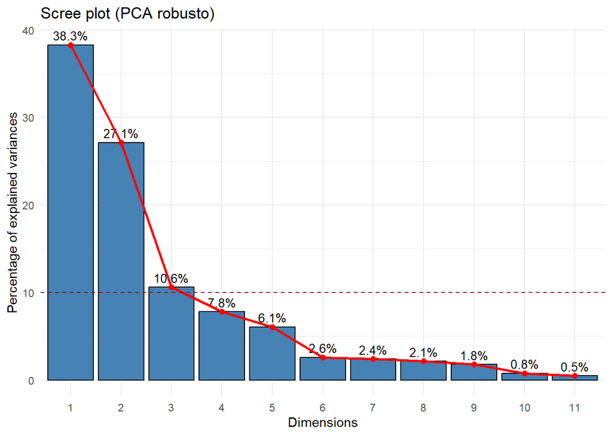

```r
# Scree plot con línea en 10
pca_rob_summary <- pca_rob_summary[order(-pca_rob_summary$Proportion), ]
pca_rob_summary$Component <- factor(pca_rob_summary$Component,
                                            levels = pca_rob_summary$Component)

ggplot(pca_rob_summary, aes(x = Component, y = Proportion * 100, group = 1)) +
  geom_bar(stat = "identity", fill = "steelblue", color = "black") +
  geom_text(aes(label = paste0(round(Proportion * 100, 1), "%")),
            vjust = -0.5, size = 3.5) +
  geom_line(color = "red", linewidth = 1) +
  geom_point(color = "red", size = 2) +
  geom_hline(yintercept = 10, linetype = "dashed", color = "darkred") +
  labs(
    title = "Scree plot (PCA robusto)",
    x = "Dimensions",
    y = "Percentage of explained variances"
  ) +
  theme_minimal()
```

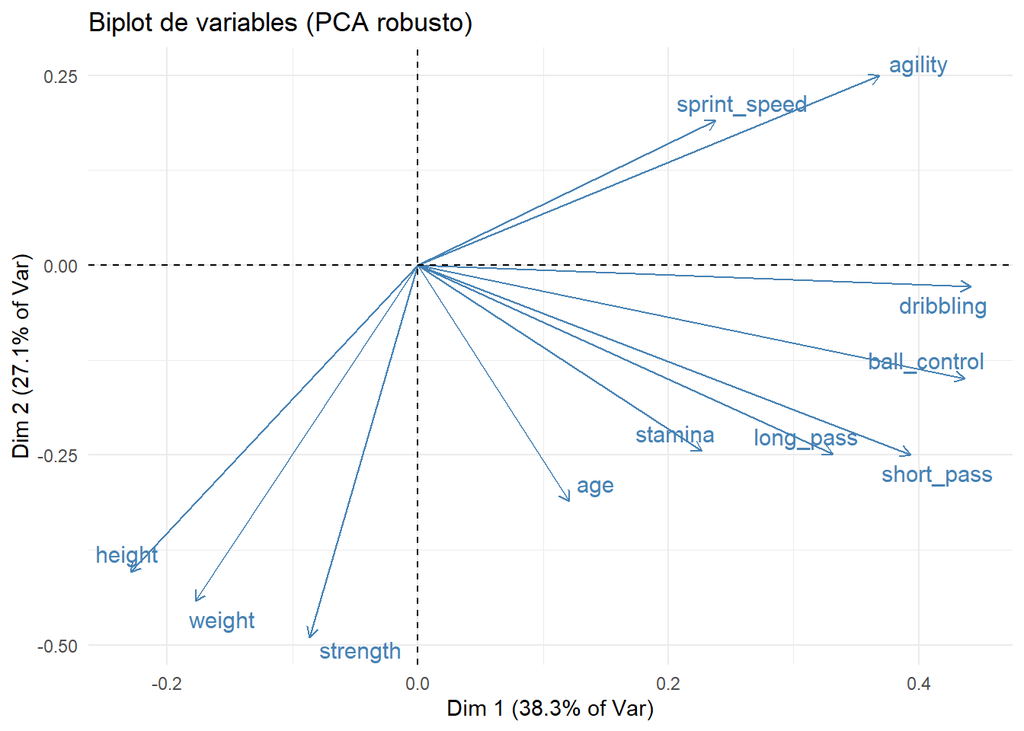

```r
# Extraer puntuaciones (scores) proyectando las observaciones
scores_rob <- as.data.frame(as.matrix(sample_pca_scaled) %*% eigenvectors)
colnames(scores_rob) <- paste0("PC", 1:ncol(scores_rob), "_rob")

# Nos quedamos solo con PC1_rob y PC2_rob
scores_rob_subset <- scores_rob[, c("PC1_rob", "PC2_rob")]

# Unir PC1_rob y PC2_rob a la base original
sample_pca_with_scores <- cbind(sample_pca_scaled, scores_rob_subset)

# Cargas factoriales (loadings)
loadings_rob <- eigenvectors[, 1:2]
rownames(loadings_rob) <- colnames(sample_pca_scaled)
colnames(loadings_rob) <- c("PC1_rob", "PC2_rob")

# Pasar a data.frame
loadings_df <- as.data.frame(loadings_rob)
loadings_df$Variable <- rownames(loadings_df)

# Biplot
ggplot(loadings_df, aes(x = 0, y = 0)) +
  geom_segment(aes(xend = PC1_rob, yend = PC2_rob),
               arrow = arrow(length = unit(0.2, "cm")),
               color = "steelblue") +
  geom_text_repel(aes(x = PC1_rob, y = PC2_rob, label = Variable),
                  size = 4, color = "steelblue") +
  geom_hline(yintercept = 0, linetype = "dashed") +
  geom_vline(xintercept = 0, linetype = "dashed") +
  labs(title = "Biplot de variables (PCA robusto)",
       x = paste0("Dim 1 (", round(proportion[1] * 100, 1), "% of Var)"),
       y = paste0("Dim 2 (", round(proportion[2] * 100, 1), "% of Var)")) +
  theme_minimal()
```

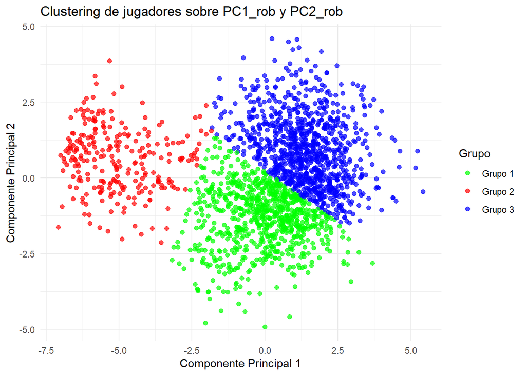

```r
# K-means con k = 3 sobre PCA robusto
kmeans_rob <- kmeans(scores_rob_subset[, c("PC1_rob", "PC2_rob")], centers = 3, nstart = 25)

# Agregar grupos al dataset
scores_rob_subset$grupo_rob <- as.factor(kmeans_rob$cluster)

# Graficar clustering
ggplot(scores_rob_subset, aes(x = PC1_rob, y = PC2_rob, color = grupo_rob)) +
  geom_point(alpha = 0.7, size = 1.8) +
  scale_color_manual(values = c("green", "red", "blue"),
                     labels = c("Grupo 1", "Grupo 2", "Grupo 3")) +
  labs(title = "Clustering de jugadores sobre PC1_rob y PC2_rob",
       x = "Componente Principal 1",
       y = "Componente Principal 2",
       color = "Grupo") +
  theme_minimal()
```